# Resting EEG band power in adolescents with schizophrenia-spectrum disorders

Jennifer Hsieh, PhD

October 2026

## Question

Is resting, eyes-closed EEG spectral power different in adolescents with schizophrenia-spectrum disorders compared with healthy adolescents, in which frequency bands and where on the scalp, and how well do these differences separate the two groups out of sample?

## Data

The MSU adolescent schizophrenia EEG database (Borisov et al., 2005): 39 healthy schoolboys and 45 boys with schizophrenia-spectrum diagnoses (ICD-10 F20, F21, F25), aged about 11 to 14, unmedicated at the time of recording. Each record is 60 s of wakeful, eyes-closed EEG from 16 scalp electrodes (10-20 system, linked-ear reference), sampled at 128 Hz and supplied as artefact-free segments. Source: http://brain.bio.msu.ru/eeg_schizophrenia.htm.

## Methods

**Cleaning and QC.** Each channel was mean-centred. Recordings were checked for missing values and flat channels (none). The 60 s were split into 29 overlapping 4-s segments, and a segment was rejected if any channel’s peak-to-peak amplitude exceeded that channel’s within-subject median + 5 MAD. Median rejected segments per subject: 0 (max 4 of 29), so no subject met the pre-specified exclusion rule (> 25% rejected). 7 channel recordings had outlying overall variance (|robust z| > 3.5, from 2 subjects); they were kept, because log band power absorbs gain differences and the data were supplied as clean.

**Spectra and features.** Welch PSD per channel (4-s Hann windows, 50% overlap, linear detrend, 0.25 Hz resolution). Band power was integrated over delta (1-4 Hz), theta (4-8), alpha (8-13) and beta (13-30), and expressed as **log10 absolute power** and **relative power** (share of 1-30 Hz). Individual **alpha peak frequency** was the maximum of the mean posterior spectrum (O1, O2, P3, P4, Pz) between 7 and 13 Hz, refined by parabolic interpolation; 2 adolescents whose maximum sat on the 7 Hz edge (no identifiable peak) were left out of that test.

**Statistics.** For each of 16 channels x 4 bands x 2 measures: Welch t-test, with a Wilcoxon rank-sum test as a robustness check, and Hedges’ *g* with 95% CI (schizophrenia minus control). P-values were corrected with Benjamini-Hochberg FDR within each measure (64 tests). For a region-level view, a linear mixed model per band, `log10 power ~ group * region + (1 | subject)` (sum contrasts, Type III, Satterthwaite df; `lmerTest`).

**Classifier.** Elastic-net logistic regression (`glmnet`, alpha = 0.5) on all 128 band-power features, with lambda chosen by inner 5-fold CV inside each outer training fold (nested CV; standardisation learned on the training fold only). Performance: 10 x repeated stratified 5-fold CV. Baseline: logistic regression on one feature, mean relative alpha across channels. Significance: 200 label permutations of the full pipeline.

## Results

### Power spectra

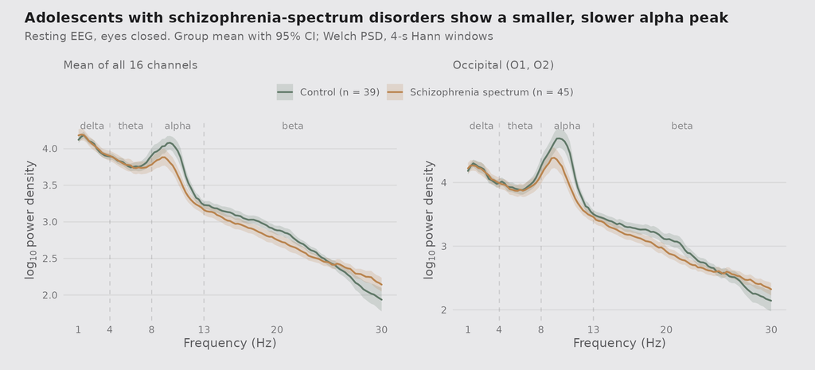

The healthy group shows the expected posterior alpha peak; in the schizophrenia group it is lower and shifted to slower frequencies, while delta and theta power look similar.

### Channel-by-band effect sizes

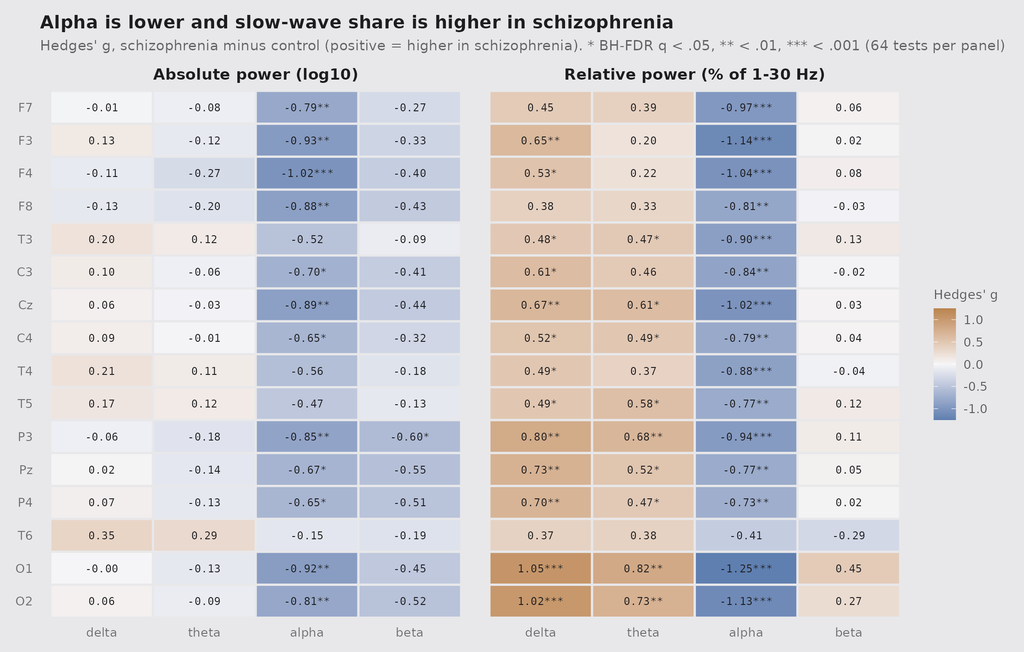

| Measure | Band | Channels FDR q<.05 (t-test) | Channels FDR q<.05 (Wilcoxon) | Hedges g range |
| --- | --- | --- | --- | --- |
| Log absolute | delta | 0 | 0 | -0.13 to 0.35 |
| Log absolute | theta | 0 | 0 | -0.27 to 0.29 |
| Log absolute | alpha | 12 | 14 | -1.02 to -0.15 |
| Log absolute | beta | 1 | 3 | -0.60 to -0.09 |
| Relative | delta | 13 | 7 | 0.37 to 1.05 |
| Relative | theta | 9 | 4 | 0.20 to 0.82 |
| Relative | alpha | 15 | 15 | -1.25 to -0.41 |
| Relative | beta | 0 | 1 | -0.29 to 0.45 |

- **Alpha is reduced** in schizophrenia: lower absolute alpha at 12 of 16 channels and lower relative alpha at 15 of 16. The largest effect is relative alpha at O1 (g = -1.25, 95% CI -1.72 to -0.78).
- **Absolute delta and theta do not differ** (all |g| < 0.36, none significant), so the higher *relative* delta and theta in schizophrenia mostly reflects the smaller alpha share, not extra slow-wave power. The relative delta/theta effects are less robust to the rank-based test.
- **Beta** trends lower in absolute terms (one channel, P3, survives FDR).

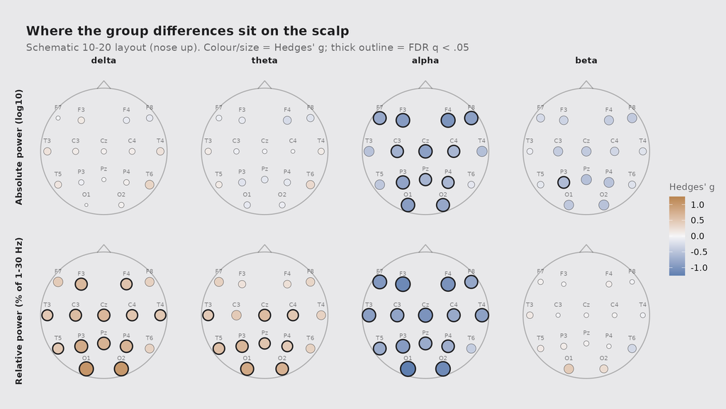

### Region-level mixed models

Absolute alpha power by region (region-averaged log10 power)

| Band | Term | F | df | p | FDR q (group) |
| --- | --- | --- | --- | --- | --- |
| delta | group | 0.13 | 1, 82 | 0.719 | 0.766 |
| delta | group:region | 2.99 | 4, 1252 | 0.018 |  |
| theta | group | 0.09 | 1, 82 | 0.766 | 0.766 |
| theta | group:region | 4.94 | 4, 1252 | 5.9e-04 |  |
| alpha | group | 15.29 | 1, 82 | 1.9e-04 | 7.6e-04 |
| alpha | group:region | 10.04 | 4, 1252 | 5.3e-08 |  |
| beta | group | 3.88 | 1, 82 | 0.052 | 0.104 |
| beta | group:region | 4.99 | 4, 1252 | 5.4e-04 |  |

| Region | Power ratio SCZ/CTL | Hedges g [95% CI] | FDR q |
| --- | --- | --- | --- |
| Frontal | 0.59 | -0.96 [-1.42, -0.51] | 3.9e-04 |
| Temporal | 0.73 | -0.46 [-0.89, -0.02] | 0.100 |
| Central | 0.62 | -0.76 [-1.20, -0.31] | 0.005 |
| Parietal | 0.54 | -0.73 [-1.18, -0.29] | 0.005 |
| Occipital | 0.46 | -0.88 [-1.33, -0.43] | 8.9e-04 |

Only alpha shows a main effect of group after FDR. Group x region interactions are significant in every band, i.e. the group difference is not uniform over the scalp: for alpha it is largest over occipital and frontal sites, where the schizophrenia group has roughly 45-60% of control alpha power.

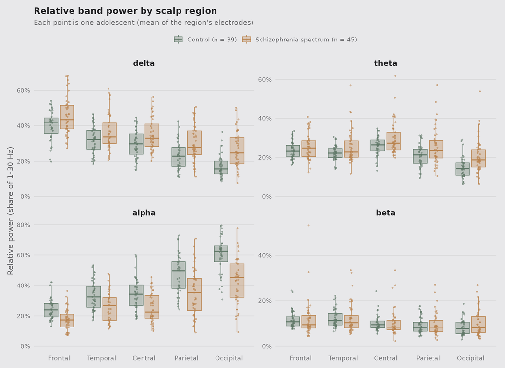

### Alpha peak frequency

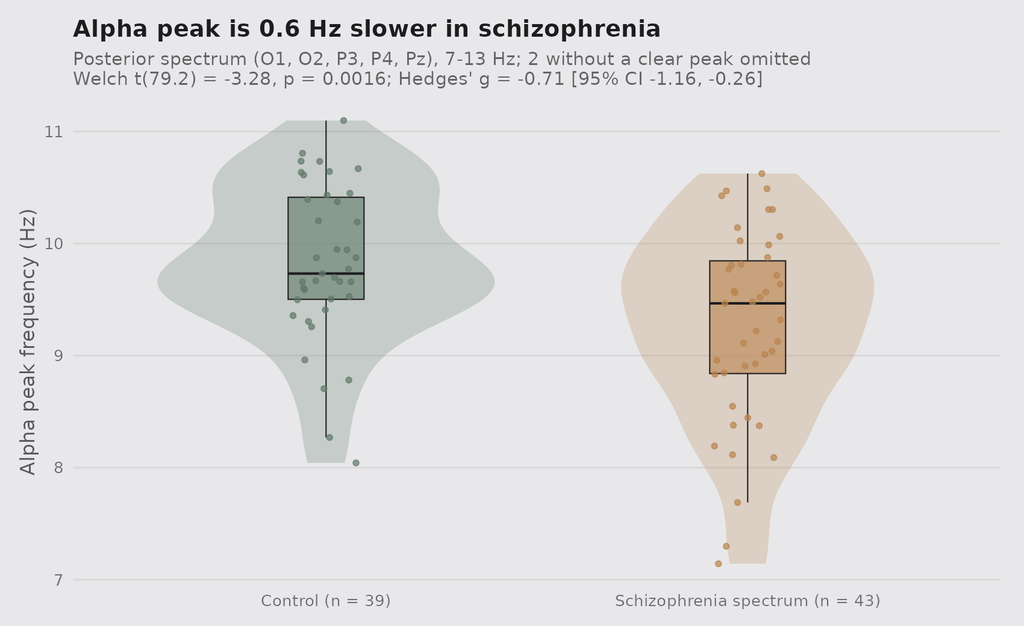

Mean alpha peak was 9.83 Hz (SD 0.70) in controls and 9.26 Hz (SD 0.86) in the schizophrenia group: Welch t(79.2) = -3.28, p = 0.002, g = -0.71 [-1.16, -0.26].

### Classification

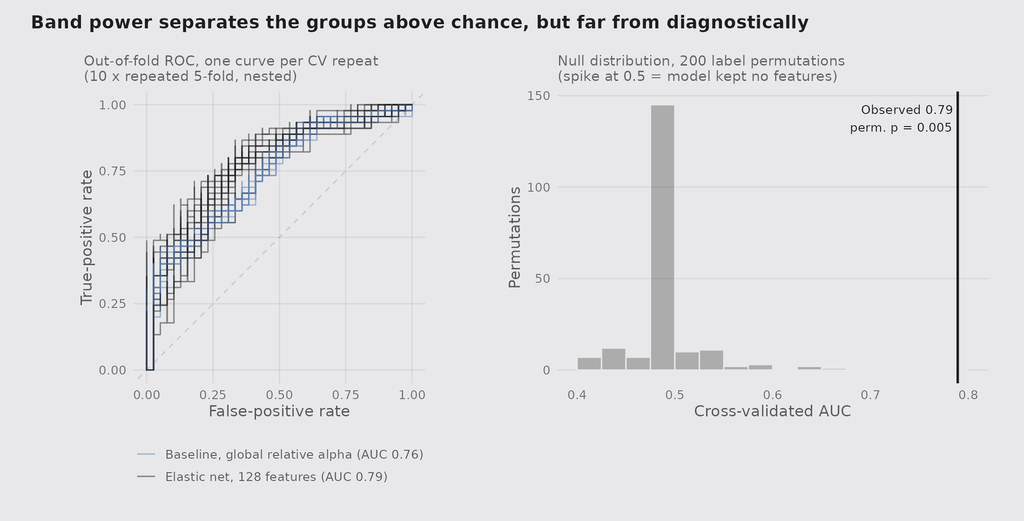

| Model | AUC mean (range over repeats) | Balanced accuracy | Permutation p |
| --- | --- | --- | --- |
| Baseline: global relative alpha | 0.76 (0.74-0.77) | 0.65 |  |
| Elastic net (128 features) | 0.79 (0.72-0.83) | 0.71 | 0.005 |

The elastic net reached a cross-validated AUC of 0.79, well above the permutation null (95th percentile 0.55; none of 200 permutations reached the observed value), but only slightly better than the single global-relative-alpha feature (AUC 0.76). The most consistently selected features were rel_alpha_O1, rel_alpha_O2, rel_alpha_F3, abs_log10_alpha_F4, rel_delta_O1: alpha again carries most of the signal.

## Interpretation

Unmedicated adolescents with schizophrenia-spectrum disorders show a **reduced and slower alpha rhythm** at rest, with otherwise similar absolute slow-wave power. This sits alongside the original authors’ report, in this same sample, of altered alpha-segment structure and reduced structural synchrony of alpha activity; here the effect shows up in plain spectral power as well. A spectral signature like this separates groups at roughly 70% balanced accuracy, which is useful for research but nowhere near a diagnostic test.

## Limitations

- Small, single-site, all-male sample from one 2005 database; no age, IQ or symptom data per subject, so age (which strongly shapes alpha frequency in adolescence) cannot be modelled directly. The authors report matched mean ages (12.3 years in both groups).
- 60 s per subject; recordings were pre-selected as artefact-free by the data providers.
- The amplitude scale in the files is larger than typical scalp EEG in microvolts, so absolute power is reported on a log scale and interpreted only relative to the other group; relative power and peak frequency are unaffected by gain.
- 50 Hz is barely visible in the spectra, which suggests the data were low-pass filtered before sharing; analysis was restricted to 1-30 Hz.
- No licence is stated on the source page; the data are not redistributed here.

## Reference

Borisov SV, Kaplan AYa, Gorbachevskaya NL, Kozlova IA (2005). Analysis of EEG structural synchrony in adolescents with schizophrenic disorders. *Human Physiology* 31(3):255-261. https://doi.org/10.1007/s10747-005-0042-z